# Exploring the Relationship between Health and Educational Outcomes

**Data Analysis with Python — Group Project**  
Cosimo ZATTI, William Manca di Villahermosa, Robert BIRKMAYER

This notebook investigates the association between three OECD health indicators (life expectancy at birth, infant mortality, health expenditure as % of GDP) and country-level PISA 2022 scores in mathematics, reading, and science.

**Structure:**

1. Setup & Data Loading
2. Exploratory Data Analysis
3. Bivariate Analysis — Facet Grid
4. Multivariate OLS Regression
5. Robustness Checks

## 1. Setup & Data Loading

```python
import pandas as pd
import numpy as np
import matplotlib.pyplot as plt
import matplotlib.gridspec as gridspec
import seaborn as sns
from pathlib import Path
from scipy import stats
import statsmodels.api as sm
import warnings
warnings.filterwarnings('ignore')

sns.set_theme(style='whitegrid', palette='muted')
plt.rcParams['figure.dpi'] = 120
```

```python
# --- File paths (relative to notebook) ---
PISA_FILE        = Path('xluqor.xlsx')
LIFE_EXP_FILE    = Path('OECD.ELS.HD,DSD_HEALTH_STAT@DF_LE,1.1,filtered,2026-04-23 15-20-54.xlsx')
INFANT_MORT_FILE = Path('OECD.ELS.HD,DSD_HEALTH_STAT@DF_MIM,1.1,filtered,2026-04-23 15-22-00.xlsx')
HEALTH_EXP_FILE  = Path('OECD.ELS.HD,DSD_SHA@DF_SHA,1.0,filtered,2026-04-23 15-25-18.xlsx')
```

```python
def load_pisa_subject(filepath, sheet_name, score_col):
    raw = pd.read_excel(filepath, sheet_name=sheet_name, header=10, engine='calamine')
    df = raw.iloc[1:, :2].copy()
    df.columns = [score_col, 'country']
    df['country'] = df['country'].astype(str).str.replace('*', '', regex=False).str.strip()
    # Harmonise names that differ between PISA and OECD health data
    df['country'] = df['country'].replace({'Czech Republic': 'Czechia'})
    df[score_col] = pd.to_numeric(df[score_col], errors='coerce')
    return df[['country', score_col]].dropna()


def load_oecd_health(filepath, col_name, year='2022'):
    raw = pd.read_excel(filepath, header=5, engine='calamine')
    df = raw[['Time period', year]].copy()
    df.columns = ['country', col_name]
    skip_exact = {'Reference area', 'Non-OECD economies', '© Terms & conditions'}
    df = df[~df['country'].astype(str).str.contains(':', na=False)]
    df = df[~df['country'].astype(str).str.strip().isin(skip_exact)]
    df['country'] = df['country'].astype(str).str.replace('·', '', regex=False).str.strip()
    df[col_name]  = pd.to_numeric(df[col_name], errors='coerce')
    df = df.dropna().drop_duplicates(subset='country', keep='first')
    return df.reset_index(drop=True)


# Load and merge PISA subjects
pisa = (
    load_pisa_subject(PISA_FILE, 'Table I.2.1', 'math_score')
    .merge(load_pisa_subject(PISA_FILE, 'Table I.2.2', 'reading_score'), on='country')
    .merge(load_pisa_subject(PISA_FILE, 'Table I.2.3', 'science_score'), on='country')
)

# Load and merge health indicators
health = (
    load_oecd_health(LIFE_EXP_FILE,    'life_expectancy')
    .merge(load_oecd_health(INFANT_MORT_FILE, 'infant_mortality'),    on='country', how='outer')
    .merge(load_oecd_health(HEALTH_EXP_FILE,  'health_exp_pct_gdp'), on='country', how='outer')
)

# Final dataset: inner join, drop rows with any missing value
df = pisa.merge(health, on='country', how='inner').dropna().reset_index(drop=True)

print(f"PISA countries:         {len(pisa)}")
print(f"OECD health countries:  {len(health)}")
print(f"Final dataset:          {len(df)} countries (complete data on all 6 variables)")
df
```

```
PISA countries:         81
OECD health countries:  53
Final dataset:          43 countries (complete data on all 6 variables)
```

|  | country | math_score | reading_score | science_score | life_expectancy | infant_mortality | health_exp_pct_gdp |
| --- | --- | --- | --- | --- | --- | --- | --- |
| 0 | Japan | 535.579306 | 515.854614 | 546.634454 | 84.1 | 1.8 | 12.322 |
| 1 | Korea | 527.302502 | 515.415392 | 527.822418 | 82.7 | 2.3 | 8.843 |
| 2 | Estonia | 509.946953 | 511.030332 | 525.811778 | 78.1 | 2.2 | 6.936 |
| 3 | Switzerland | 507.990586 | 483.331734 | 502.523242 | 83.7 | 3.8 | 11.599 |
| 4 | Canada | 496.947894 | 507.132896 | 515.016676 | 81.3 | 4.7 | 11.081 |
| 5 | Netherlands | 492.675639 | 459.242908 | 488.316836 | 81.7 | 3.2 | 10.031 |
| 6 | Ireland | 491.648280 | 516.009975 | 503.845537 | 82.6 | 3.5 | 6.021 |
| 7 | Belgium | 489.486817 | 478.852668 | 490.578346 | 81.8 | 2.9 | 10.740 |
| 8 | Denmark | 489.273877 | 488.800991 | 493.815712 | 81.3 | 2.3 | 9.474 |
| 9 | United Kingdom | 488.975085 | 494.404626 | 499.670214 | 80.9 | 4.0 | 11.097 |
| 10 | Poland | 488.960054 | 488.713629 | 499.164362 | 77.2 | 3.8 | 6.466 |
| 11 | Austria | 487.267499 | 480.405847 | 491.270959 | 81.4 | 2.4 | 11.225 |
| 12 | Australia | 487.084254 | 498.050940 | 507.000869 | 83.2 | 3.2 | 9.892 |
| 13 | Czechia | 486.999208 | 488.603668 | 497.742047 | 79.0 | 2.3 | 8.471 |
| 14 | Slovenia | 484.529009 | 468.536013 | 499.964882 | 81.3 | 2.5 | 9.627 |
| 15 | Finland | 484.139226 | 490.217685 | 510.958851 | 81.2 | 2.0 | 9.742 |
| 16 | Latvia | 483.159455 | 474.568651 | 493.842767 | 74.5 | 2.4 | 8.104 |
| 17 | Sweden | 481.766065 | 486.975156 | 493.549319 | 83.1 | 2.2 | 10.946 |
| 18 | Lithuania | 475.146762 | 471.834230 | 484.463406 | 75.8 | 3.0 | 7.244 |
| 19 | Germany | 474.826454 | 479.794025 | 492.426730 | 80.7 | 3.2 | 12.447 |
| 20 | France | 473.944418 | 473.852158 | 487.225279 | 82.3 | 4.0 | 11.835 |
| 21 | Spain | 473.140208 | 474.307112 | 484.533648 | 83.2 | 2.6 | 9.680 |
| 22 | Hungary | 472.776122 | 472.974726 | 485.890159 | 76.0 | 3.6 | 6.647 |
| 23 | Portugal | 471.910522 | 476.588611 | 484.373464 | 81.8 | 2.6 | 10.549 |
| 24 | Italy | 471.259475 | 481.598278 | 477.463366 | 82.8 | 2.3 | 8.850 |
| 25 | Norway | 468.449950 | 476.523878 | 478.226465 | 82.5 | 1.9 | 7.909 |
| 26 | United States | 464.888043 | 503.937574 | 499.414064 | 77.5 | 5.6 | 16.529 |
| 27 | Slovak Republic | 463.994618 | 446.860607 | 462.269483 | 77.0 | 5.4 | 7.702 |
| 28 | Croatia | 463.105189 | 475.498946 | 482.667449 | 77.7 | 4.1 | 7.297 |
| 29 | Iceland | 458.896450 | 435.898028 | 446.926795 | 82.1 | 1.4 | 9.081 |
| 30 | Israel | 457.896667 | 473.832698 | 464.751825 | 82.8 | 2.9 | 7.120 |
| 31 | Türkiye | 453.151767 | 456.084041 | 475.937802 | 77.3 | 9.1 | 3.703 |
| 32 | Greece | 430.146322 | 438.440625 | 440.786060 | 80.8 | 3.0 | 8.449 |
| 33 | Romania | 427.759997 | 428.496017 | 427.511108 | 75.1 | 5.7 | 5.798 |
| 34 | Bulgaria | 417.303900 | 404.303740 | 420.993219 | 74.2 | 4.8 | 7.638 |
| 35 | Chile | 411.696571 | 447.978957 | 443.543402 | 81.2 | 5.9 | 10.005 |
| 36 | Mexico | 395.029919 | 415.358962 | 409.886598 | 75.2 | 12.1 | 5.709 |
| 37 | Thailand | 393.945356 | 378.663004 | 409.264309 | 75.3 | 8.3 | 5.355 |
| 38 | Peru | 391.235785 | 408.247856 | 407.777761 | 77.1 | 17.0 | 6.097 |
| 39 | Costa Rica | 384.576041 | 415.233080 | 410.986624 | 80.9 | 9.5 | 7.184 |
| 40 | Brazil | 378.691367 | 410.356979 | 403.001214 | 74.9 | 12.6 | 9.387 |
| 41 | Argentina | 377.529029 | 400.744043 | 406.191341 | 75.8 | 8.3 | 10.496 |
| 42 | Indonesia | 365.525254 | 358.569859 | 382.863413 | 70.9 | 17.5 | 2.694 |

## 2. Exploratory Data Analysis

```python
# --- 2a. Descriptive statistics ---
df.describe().round(2)
```

|  | math_score | reading_score | science_score | life_expectancy | infant_mortality | health_exp_pct_gdp |
| --- | --- | --- | --- | --- | --- | --- |
| count | 43.00 | 43.00 | 43.00 | 43.00 | 43.00 | 43.00 |
| mean | 461.18 | 464.00 | 473.42 | 79.53 | 4.83 | 8.79 |
| std | 42.28 | 38.21 | 39.48 | 3.31 | 3.85 | 2.57 |
| min | 365.53 | 358.57 | 382.86 | 70.90 | 1.40 | 2.69 |
| 25% | 441.65 | 442.65 | 445.24 | 77.05 | 2.40 | 7.15 |
| 50% | 473.14 | 474.57 | 485.89 | 80.90 | 3.20 | 8.85 |
| 75% | 488.11 | 488.66 | 499.29 | 82.20 | 5.50 | 10.52 |
| max | 535.58 | 516.01 | 546.63 | 84.10 | 17.50 | 16.53 |

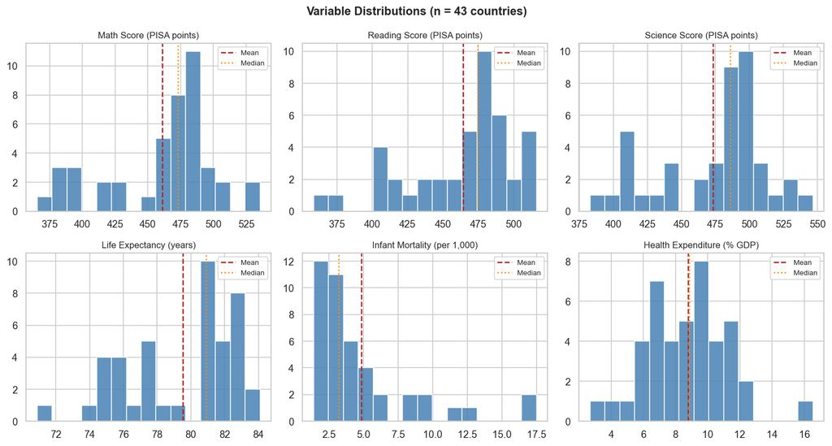

```python
# --- 2b. Distributions ---
vars_info = {
    'math_score':         'Math Score (PISA points)',
    'reading_score':      'Reading Score (PISA points)',
    'science_score':      'Science Score (PISA points)',
    'life_expectancy':    'Life Expectancy (years)',
    'infant_mortality':   'Infant Mortality (per 1,000)',
    'health_exp_pct_gdp': 'Health Expenditure (% GDP)',
}

fig, axes = plt.subplots(2, 3, figsize=(13, 7))
for ax, (col, label) in zip(axes.flat, vars_info.items()):
    ax.hist(df[col], bins=15, edgecolor='white', color='steelblue', alpha=0.85)
    ax.axvline(df[col].mean(),   color='firebrick', linewidth=1.5, linestyle='--', label='Mean')
    ax.axvline(df[col].median(), color='darkorange', linewidth=1.5, linestyle=':',  label='Median')
    ax.set_title(label, fontsize=10)
    ax.legend(fontsize=8)

fig.suptitle('Variable Distributions (n = 43 countries)', fontsize=13, fontweight='bold')
plt.tight_layout()
plt.savefig('distributions.png', bbox_inches='tight', dpi=150)
plt.show()
```

```python
# --- 2c. Pearson + Spearman correlations with p-values ---
health_vars = ['life_expectancy', 'infant_mortality', 'health_exp_pct_gdp']
pisa_vars   = ['math_score', 'reading_score', 'science_score']

rows = []
for hv in health_vars:
    for pv in pisa_vars:
        pr, pp = stats.pearsonr(df[hv],  df[pv])
        sr, sp = stats.spearmanr(df[hv], df[pv])
        rows.append({
            'Health indicator': hv.replace('_', ' ').title(),
            'PISA subject':     pv.replace('_score', '').title(),
            'Pearson r':        round(pr, 3),
            'Pearson p':        round(pp, 3),
            'Spearman ρ':       round(sr, 3),
            'Spearman p':       round(sp, 3),
        })

corr_table = pd.DataFrame(rows)
print("Correlations between health indicators and PISA scores (n=43)")
print("* p < 0.05   ** p < 0.01   *** p < 0.001")
print()

def star(p):
    if p < 0.001: return '***'
    if p < 0.01:  return '**'
    if p < 0.05:  return '*'
    return ''

corr_table['Pearson r']  = corr_table.apply(lambda r: f"{r['Pearson r']}{star(r['Pearson p'])}",  axis=1)
corr_table['Spearman ρ'] = corr_table.apply(lambda r: f"{r['Spearman ρ']}{star(r['Spearman p'])}", axis=1)
corr_table[['Health indicator', 'PISA subject', 'Pearson r', 'Pearson p', 'Spearman ρ', 'Spearman p']]
```

```
Correlations between health indicators and PISA scores (n=43)
* p < 0.05   ** p < 0.01   *** p < 0.001
```

|  | Health indicator | PISA subject | Pearson r | Pearson p | Spearman ρ | Spearman p |
| --- | --- | --- | --- | --- | --- | --- |
| 0 | Life Expectancy | Math | 0.619*** | 0.000 | 0.555*** | 0.000 |
| 1 | Life Expectancy | Reading | 0.647*** | 0.000 | 0.579*** | 0.000 |
| 2 | Life Expectancy | Science | 0.605*** | 0.000 | 0.517*** | 0.000 |
| 3 | Infant Mortality | Math | -0.807*** | 0.000 | -0.619*** | 0.000 |
| 4 | Infant Mortality | Reading | -0.75*** | 0.000 | -0.583*** | 0.000 |
| 5 | Infant Mortality | Science | -0.768*** | 0.000 | -0.584*** | 0.000 |
| 6 | Health Exp Pct Gdp | Math | 0.427** | 0.004 | 0.435** | 0.004 |
| 7 | Health Exp Pct Gdp | Reading | 0.496** | 0.001 | 0.442** | 0.003 |
| 8 | Health Exp Pct Gdp | Science | 0.477** | 0.001 | 0.459** | 0.002 |

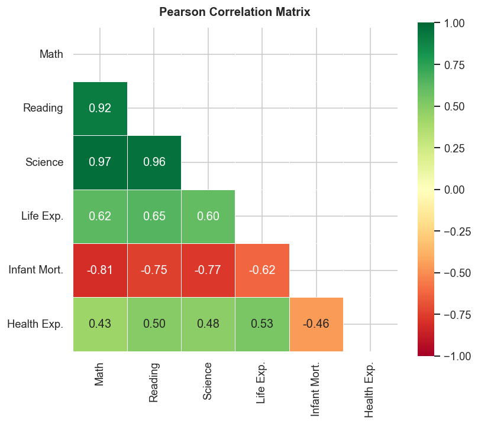

```python
# --- 2d. Full correlation heatmap (Pearson) ---
all_vars = pisa_vars + health_vars
labels   = ['Math', 'Reading', 'Science', 'Life Exp.', 'Infant Mort.', 'Health Exp.']

corr_matrix = df[all_vars].corr()
corr_matrix.index   = labels
corr_matrix.columns = labels

fig, ax = plt.subplots(figsize=(7, 6))
mask = np.zeros_like(corr_matrix, dtype=bool)
mask[np.triu_indices_from(mask)] = True   # upper triangle
sns.heatmap(corr_matrix, annot=True, fmt='.2f', cmap='RdYlGn', center=0,
            mask=mask, linewidths=0.5, square=True, ax=ax,
            vmin=-1, vmax=1)
ax.set_title('Pearson Correlation Matrix', fontsize=12, fontweight='bold', pad=12)
plt.tight_layout()
plt.savefig('correlation_heatmap.png', bbox_inches='tight', dpi=150)
plt.show()
```

## 3. Bivariate Analysis — Facet Grid

Each panel shows the scatter plot of one health indicator (rows) against one PISA subject (columns), with an OLS regression line, 95% CI, R², and p-value annotated.

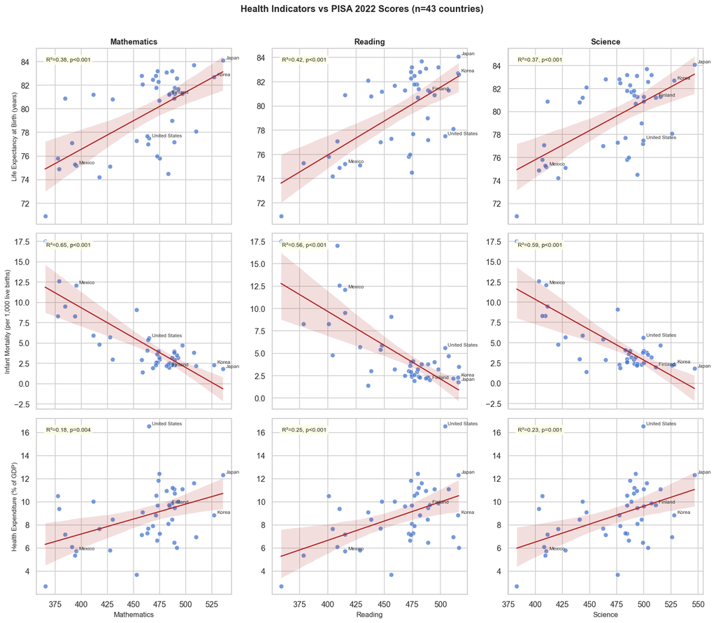

```python
health_labels = {
    'life_expectancy':    'Life Expectancy at Birth (years)',
    'infant_mortality':   'Infant Mortality (per 1,000 live births)',
    'health_exp_pct_gdp': 'Health Expenditure (% of GDP)',
}
pisa_labels = {
    'math_score':    'Mathematics',
    'reading_score': 'Reading',
    'science_score': 'Science',
}
highlight = ['United States', 'Japan', 'Korea', 'Finland', 'Mexico', 'Singapore']

fig, axes = plt.subplots(3, 3, figsize=(14, 12), sharex='col')

for row_idx, (hv, hl) in enumerate(health_labels.items()):
    for col_idx, (pv, pl) in enumerate(pisa_labels.items()):
        ax = axes[row_idx, col_idx]

        sns.regplot(data=df, x=pv, y=hv, ax=ax,
                    scatter_kws=dict(s=40, alpha=0.75, edgecolors='white', linewidths=0.5),
                    line_kws=dict(color='firebrick', linewidth=1.5), ci=95)

        # Annotate notable countries
        for _, row in df[df['country'].isin(highlight)].iterrows():
            ax.annotate(row['country'], xy=(row[pv], row[hv]),
                        xytext=(4, 2), textcoords='offset points',
                        fontsize=7, color='#333333')

        # R² and p-value annotation
        r, p = stats.pearsonr(df[pv], df[hv])
        r2 = r**2
        p_str = f'p={p:.3f}' if p >= 0.001 else 'p<0.001'
        ax.text(0.05, 0.95, f'R²={r2:.2f}, {p_str}',
                transform=ax.transAxes, fontsize=8, va='top',
                bbox=dict(boxstyle='round,pad=0.3', facecolor='lightyellow', alpha=0.8))

        if row_idx == 2: ax.set_xlabel(pl, fontsize=10)
        else:            ax.set_xlabel('')
        if col_idx == 0: ax.set_ylabel(hl, fontsize=9)
        else:            ax.set_ylabel('')
        if row_idx == 0: ax.set_title(pl, fontsize=11, fontweight='bold')

fig.suptitle('Health Indicators vs PISA 2022 Scores (n=43 countries)',
             fontsize=13, fontweight='bold', y=1.01)
plt.tight_layout()
plt.savefig('facet_grid.png', bbox_inches='tight', dpi=150)
plt.show()
```

## 4. Multivariate OLS Regression

We regress each PISA subject score on all three health indicators simultaneously. This allows us to assess the **partial association** of each indicator while holding the others constant, and to evaluate **joint explanatory power** (R²).

Predictors are **standardised** (z-scores) so coefficients are directly comparable across indicators.

```python
# Standardise all variables (z-scores)
df_z = df.copy()
for col in pisa_vars + health_vars:
    df_z[col] = (df[col] - df[col].mean()) / df[col].std()

X = sm.add_constant(df_z[health_vars])
X.columns = ['Intercept', 'Life Expectancy', 'Infant Mortality', 'Health Expenditure']

results = {}
for pv in pisa_vars:
    results[pv] = sm.OLS(df_z[pv], X).fit()

# Summary table
rows = []
for pv, res in results.items():
    subject = pv.replace('_score', '').title()
    for coef_name in ['Life Expectancy', 'Infant Mortality', 'Health Expenditure']:
        rows.append({
            'PISA Subject':     subject,
            'Predictor':        coef_name,
            'β (std.)':         round(res.params[coef_name], 3),
            'Std. Error':       round(res.bse[coef_name], 3),
            't-stat':           round(res.tvalues[coef_name], 2),
            'p-value':          round(res.pvalues[coef_name], 3),
            'Sig.':             star(res.pvalues[coef_name]),
            'R²':               round(res.rsquared, 3),
            'Adj. R²':          round(res.rsquared_adj, 3),
        })

reg_table = pd.DataFrame(rows)
print("Multivariate OLS Regression — standardised coefficients")
print("Dependent variable: standardised PISA score\n")
reg_table
```

```
Multivariate OLS Regression — standardised coefficients
Dependent variable: standardised PISA score
```

|  | PISA Subject | Predictor | β (std.) | Std. Error | t-stat | p-value | Sig. | R² | Adj. R² |
| --- | --- | --- | --- | --- | --- | --- | --- | --- | --- |
| 0 | Math | Life Expectancy | 0.181 | 0.125 | 1.45 | 0.156 |  | 0.674 | 0.648 |
| 1 | Math | Infant Mortality | -0.686 | 0.119 | -5.76 | 0.000 | *** | 0.674 | 0.648 |
| 2 | Math | Health Expenditure | 0.017 | 0.110 | 0.15 | 0.879 |  | 0.674 | 0.648 |
| 3 | Reading | Life Expectancy | 0.246 | 0.134 | 1.83 | 0.075 |  | 0.624 | 0.595 |
| 4 | Reading | Infant Mortality | -0.543 | 0.128 | -4.24 | 0.000 | *** | 0.624 | 0.595 |
| 5 | Reading | Health Expenditure | 0.117 | 0.118 | 0.99 | 0.326 |  | 0.624 | 0.595 |
| 6 | Science | Life Expectancy | 0.161 | 0.135 | 1.20 | 0.239 |  | 0.623 | 0.594 |
| 7 | Science | Infant Mortality | -0.617 | 0.128 | -4.82 | 0.000 | *** | 0.623 | 0.594 |
| 8 | Science | Health Expenditure | 0.110 | 0.118 | 0.93 | 0.359 |  | 0.623 | 0.594 |

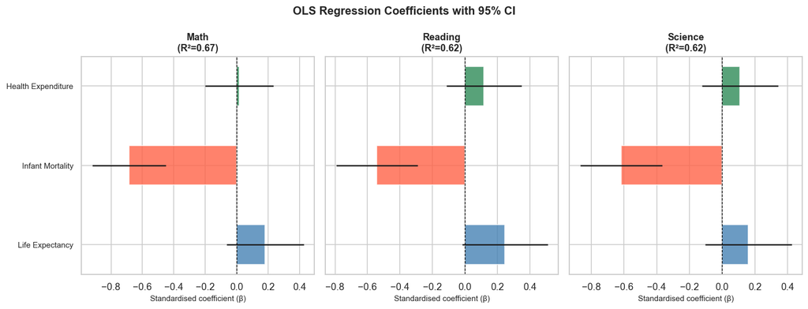

```python
# Coefficient plot
fig, axes = plt.subplots(1, 3, figsize=(13, 5), sharey=True)
colors = {'Life Expectancy': 'steelblue', 'Infant Mortality': 'tomato', 'Health Expenditure': 'seagreen'}

for ax, pv in zip(axes, pisa_vars):
    res = results[pv]
    predictors = ['Life Expectancy', 'Infant Mortality', 'Health Expenditure']
    coefs  = [res.params[p] for p in predictors]
    errors = [res.bse[p] * 1.96 for p in predictors]  # 95% CI

    y_pos = range(len(predictors))
    ax.barh(y_pos, coefs, xerr=errors, align='center',
            color=[colors[p] for p in predictors], alpha=0.8,
            edgecolor='white', height=0.5)
    ax.axvline(0, color='black', linewidth=0.8, linestyle='--')
    ax.set_yticks(y_pos)
    ax.set_yticklabels(predictors, fontsize=9)
    ax.set_title(f"{pv.replace('_score','').title()}\n(R²={res.rsquared:.2f})",
                 fontsize=11, fontweight='bold')
    ax.set_xlabel('Standardised coefficient (β)', fontsize=9)

fig.suptitle('OLS Regression Coefficients with 95% CI', fontsize=13, fontweight='bold')
plt.tight_layout()
plt.savefig('regression_coefficients.png', bbox_inches='tight', dpi=150)
plt.show()
```

## 5. Robustness Checks

### 5a. Log-transformation of infant mortality

Infant mortality is right-skewed (range: 1.4–17.5). A log transformation linearises the relationship with PISA scores and reduces the leverage of extreme values.

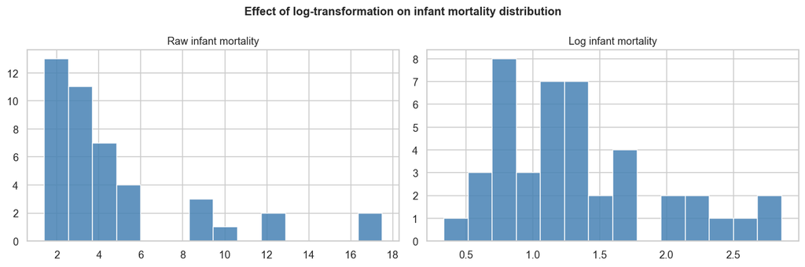

```
Pearson r: raw vs log-transformed infant mortality
```

[output not shown]

```python
df['log_infant_mortality'] = np.log(df['infant_mortality'])

fig, axes = plt.subplots(1, 2, figsize=(12, 4))

for ax, col, title in zip(axes,
                           ['infant_mortality', 'log_infant_mortality'],
                           ['Raw infant mortality', 'Log infant mortality']):
    ax.hist(df[col], bins=14, edgecolor='white', color='steelblue', alpha=0.85)
    ax.set_title(title, fontsize=11)

plt.suptitle('Effect of log-transformation on infant mortality distribution',
             fontsize=12, fontweight='bold')
plt.tight_layout()
plt.show()

# Compare Pearson r — raw vs log
rows = []
for pv in pisa_vars:
    r_raw,  p_raw  = stats.pearsonr(df['infant_mortality'],     df[pv])
    r_log,  p_log  = stats.pearsonr(df['log_infant_mortality'], df[pv])
    rows.append({
        'PISA subject':             pv.replace('_score','').title(),
        'r (raw infant mort.)':     f'{r_raw:.3f} (p={p_raw:.3f})',
        'r (log infant mort.)':     f'{r_log:.3f} (p={p_log:.3f})',
    })
print("Pearson r: raw vs log-transformed infant mortality")
pd.DataFrame(rows)
```

### 5b. Sensitivity analysis — excluding the United States

```python
df_no_us = df[df['country'] != 'United States'].reset_index(drop=True)

rows = []
for hv in health_vars:
    for pv in pisa_vars:
        r_full, p_full = stats.pearsonr(df[hv],       df[pv])
        r_nous, p_nous = stats.pearsonr(df_no_us[hv], df_no_us[pv])
        rows.append({
            'Health indicator': hv.replace('_', ' ').title(),
            'PISA subject':     pv.replace('_score', '').title(),
            f'r  full (n={len(df)})':    f'{r_full:.3f}{star(p_full)}',
            f'r  excl. US (n={len(df_no_us)})': f'{r_nous:.3f}{star(p_nous)}',
            'Direction stable': '✓' if np.sign(r_full) == np.sign(r_nous) else '✗',
        })

print("Sensitivity: full sample vs excluding the United States")
print("* p<0.05  ** p<0.01  *** p<0.001")
pd.DataFrame(rows)
```

```
Sensitivity: full sample vs excluding the United States
* p<0.05  ** p<0.01  *** p<0.001
```

|  | Health indicator | PISA subject | r full (n=43) | r excl. US (n=42) | Direction stable |
| --- | --- | --- | --- | --- | --- |
| 0 | Life Expectancy | Math | 0.619*** | 0.623*** | ✓ |
| 1 | Life Expectancy | Reading | 0.647*** | 0.675*** | ✓ |
| 2 | Life Expectancy | Science | 0.605*** | 0.621*** | ✓ |
| 3 | Infant Mortality | Math | -0.807*** | -0.808*** | ✓ |
| 4 | Infant Mortality | Reading | -0.750*** | -0.765*** | ✓ |
| 5 | Infant Mortality | Science | -0.768*** | -0.775*** | ✓ |
| 6 | Health Exp Pct Gdp | Math | 0.427** | 0.476** | ✓ |
| 7 | Health Exp Pct Gdp | Reading | 0.496*** | 0.481** | ✓ |
| 8 | Health Exp Pct Gdp | Science | 0.477** | 0.488** | ✓ |

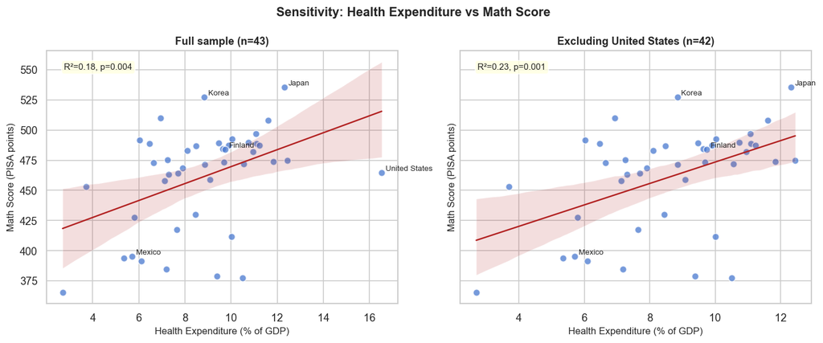

```python
# Visual: health expenditure vs math — with and without US
fig, axes = plt.subplots(1, 2, figsize=(12, 5), sharey=True)

for ax, data, title in zip(axes,
                            [df, df_no_us],
                            [f'Full sample (n={len(df)})',
                             f'Excluding United States (n={len(df_no_us)})']):
    r, p = stats.pearsonr(data['health_exp_pct_gdp'], data['math_score'])
    sns.regplot(data=data, x='health_exp_pct_gdp', y='math_score', ax=ax,
                scatter_kws=dict(s=50, alpha=0.75, edgecolors='white'),
                line_kws=dict(color='firebrick', linewidth=1.5), ci=95)
    for _, row in data[data['country'].isin(['United States','Japan','Korea','Finland','Mexico'])].iterrows():
        ax.annotate(row['country'], xy=(row['health_exp_pct_gdp'], row['math_score']),
                    xytext=(4, 2), textcoords='offset points', fontsize=8)
    p_str = f'p={p:.3f}' if p >= 0.001 else 'p<0.001'
    ax.text(0.05, 0.95, f'R²={r**2:.2f}, {p_str}',
            transform=ax.transAxes, fontsize=9, va='top',
            bbox=dict(boxstyle='round,pad=0.3', facecolor='lightyellow', alpha=0.8))
    ax.set_title(title, fontsize=11, fontweight='bold')
    ax.set_xlabel('Health Expenditure (% of GDP)', fontsize=10)
    ax.set_ylabel('Math Score (PISA points)', fontsize=10)

fig.suptitle('Sensitivity: Health Expenditure vs Math Score', fontsize=13, fontweight='bold')
plt.tight_layout()
plt.savefig('sensitivity_us.png', bbox_inches='tight', dpi=150)
plt.show()
```

## Summary of Findings

[output not shown]